# Economías Emergentes

Marzo 2019

## Economías emergentes: ¿Qué son?

- No existe ninguna definición precisa
- ¿Pero que pensamos nosotros?

## Lazos comerciales

Una fracción no trivial del comercio internacional español es con países emergentes

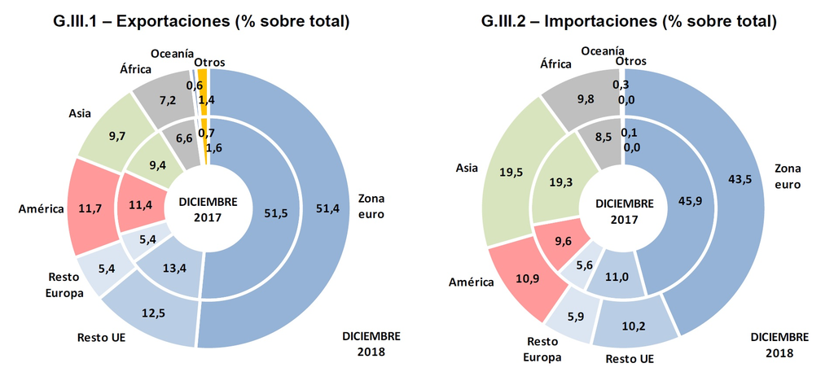

## Lazos comerciales

Gran parte de la inversión española en el exterior está en economías emergentes

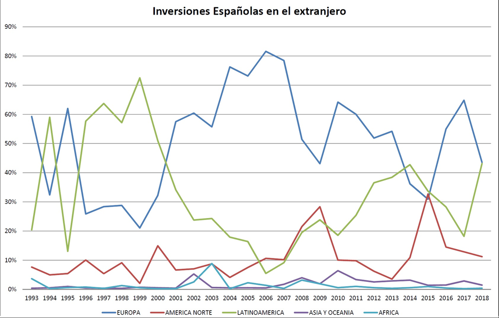

## Lazos financieros

Durante años las necesidades de financiación han sido cubiertas por el resto del mundo

[figure not shown]

## Lazos financieros

Durante años las necesidades de financiación han sido cubiertas por el resto del mundo

[figure not shown]

## Economías emergentes: Características

- Menor ingreso por persona

## Economías emergentes: Características

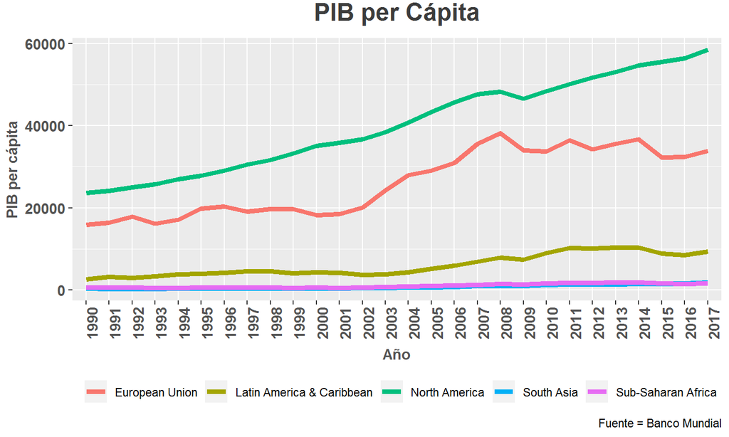

## Economías emergentes: Características

- Menor ingreso por persona
- ¿Más desigualdad?

## Economías emergentes: Características

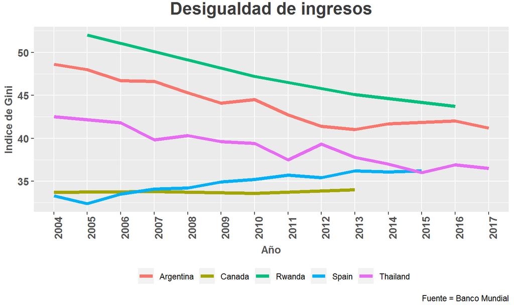

## Economías emergentes: Características

- Menor ingreso por persona
- ¿Más desigualdad?
- Peor calidad institucional
- Menor acceso a servicios públicos
- Menor nivel de desarrollo humano, etc.

## Economías emergentes: Características

Ahora nos concentramos en lo estrictamente **ECONÓMICO**

## Economías emergentes: Características

Las economías emergentes tienden a ser más *abiertas* , es decir, el comercio internacional tiene un mayor peso en su economía.

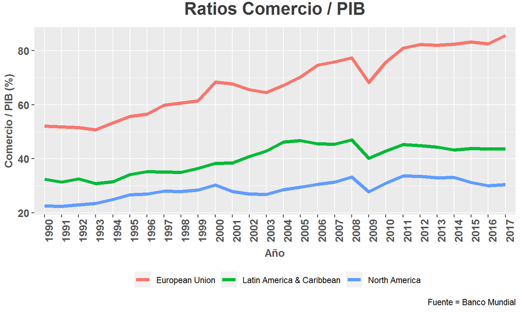

## Economías emergentes: Características

| País | Media |
| --- | --- |
| East Asia & Pacific | 54.22541 |
| European Union | 68.11252 |
| Japan | 24.91985 |
| Latin America & Caribbean | 39.92639 |
| Middle East & North Africa | 73.12435 |
| North America | 28.69831 |
| Sub-Saharan Africa | 55.20591 |

## Economías emergentes: Características

Las economías emergentes tienden a ser más *abiertas* , es decir, el comercio internacional tiene un mayor peso en su economía.

*FALSO*

## Economías emergentes: Características

Las economías emergentes tienden a concentrar sus exportaciones en **materias primas**

## Economías emergentes: Características

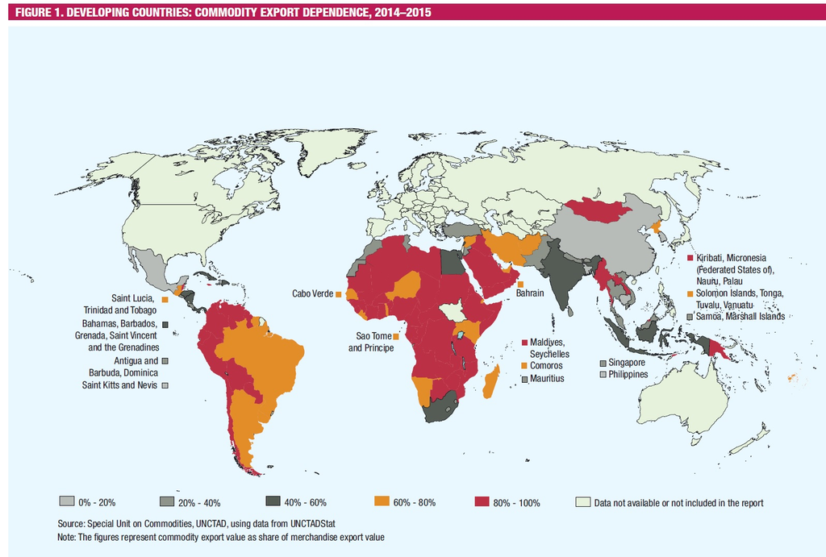

## Economías emergentes: Características

En España (por ejemplo) el comercio no está concentrado en materias primas

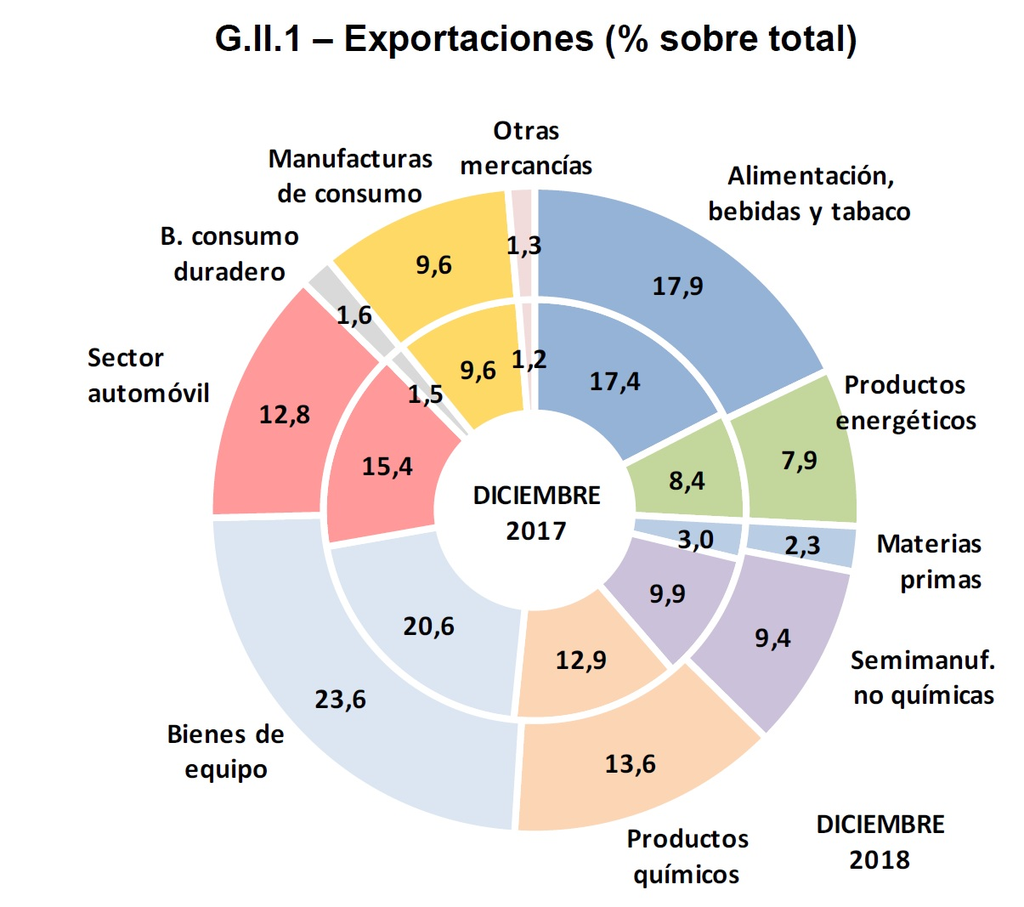

## Economías emergentes: Características

En España (por ejemplo) el comercio no está concentrado en materias primas

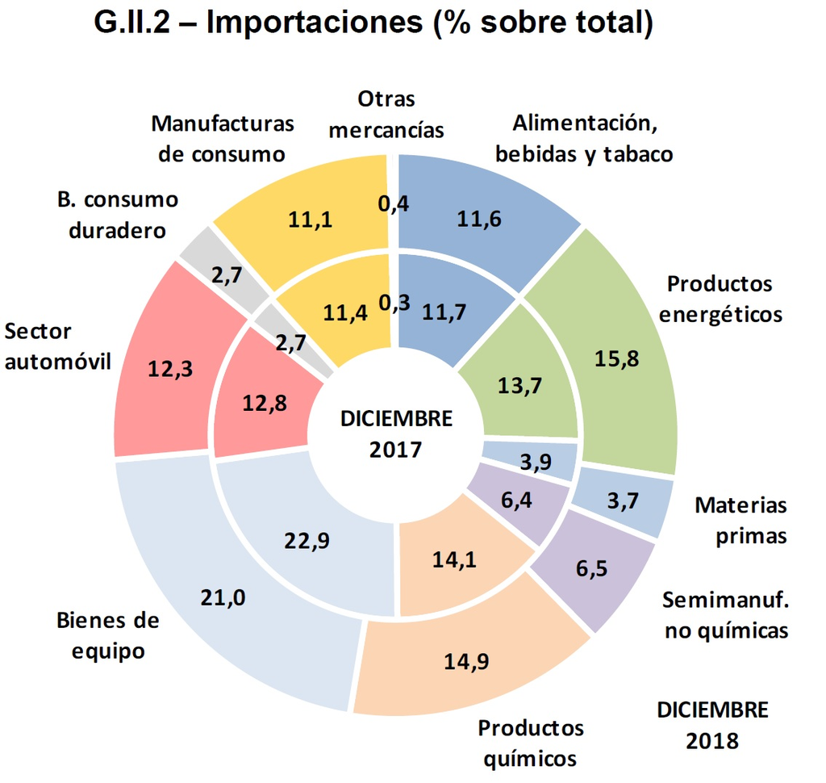

## Economías emergentes: Características

Los precios internacionales de las materias primas son más volátiles

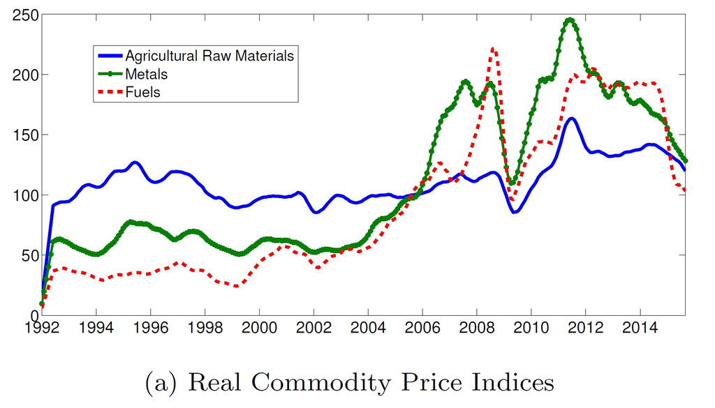

## Economías emergentes: Características

Y la consecuencia de esto es …

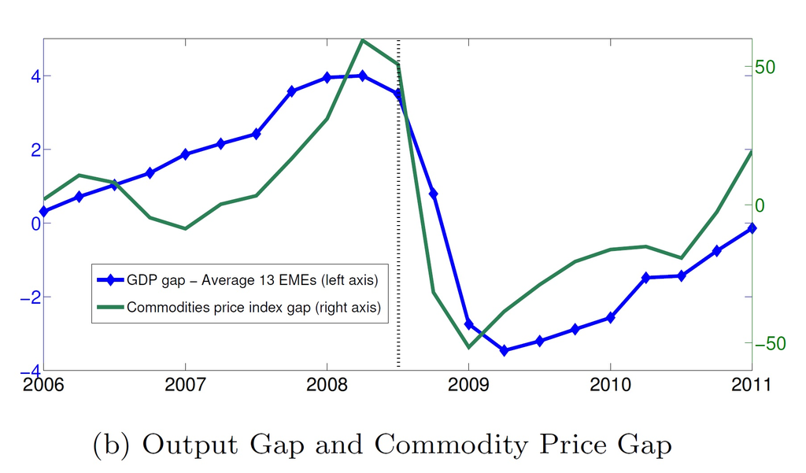

## Economías emergentes: Características

¿Y si comparamos los términos de intercambio de los países avanzados y emergentes?

## Economías emergentes: Características

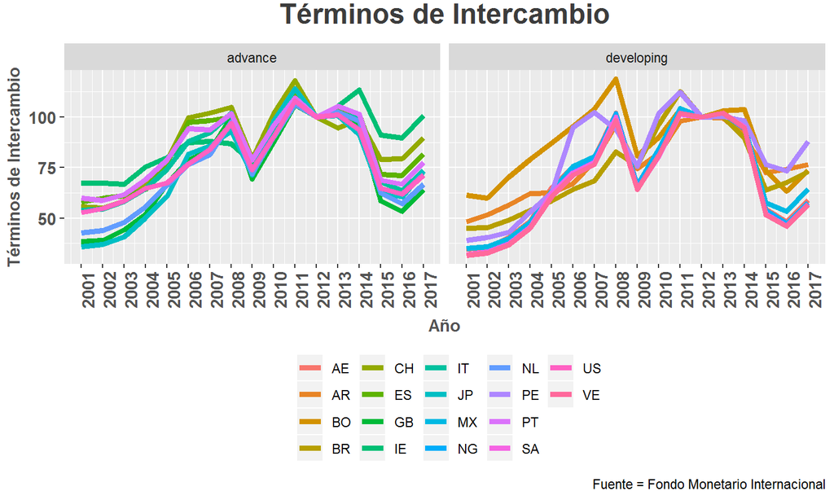

## Economías emergentes: Características

- En el aspecto fiscal, las diferencias entre economías avanzadas y emergentes son notables
- Dicho aspecto es relevante, ya que condiciona la capacidad de estado para ofrecer servicios públicos

## Economías emergentes: Características

| Conceptos | Emerging Market and Middle-Income Economies | Major Advanced Economies - G7 | Advanced Economies (IMF) | Emerging Market Latin America |
| --- | --- | --- | --- | --- |
| Balance | -1.871421 | -4.556874 | -3.754435 | -3.119174 |
| Expenditure | 28.863887 | 39.754507 | 39.529258 | 31.353223 |
| Gross debt | 41.356437 | 99.699018 | 89.103941 | 51.401823 |
| Revenue | 26.992977 | 35.197634 | 35.774823 | 28.234049 |

## Economías emergentes: Características

Otra característica peculiar de las economías emergentes es la emisión de deuda en moneda **distinta a la local**

*(Pecado original)*

## Economías emergentes: Características

[figure not shown]

## Economías emergentes: Características

- Las condiciones en las que empresas, hogares y sector público pueden acceder a financiación en las economías emergentes difiere de las avanzadas.
- Las diferencias institucionales (sistema financiero) son relevantes, pero nos concentramos en un solo aspecto, **el coste de financiación**

## Economías emergentes: Características

El coste de financiación es mucho mayor

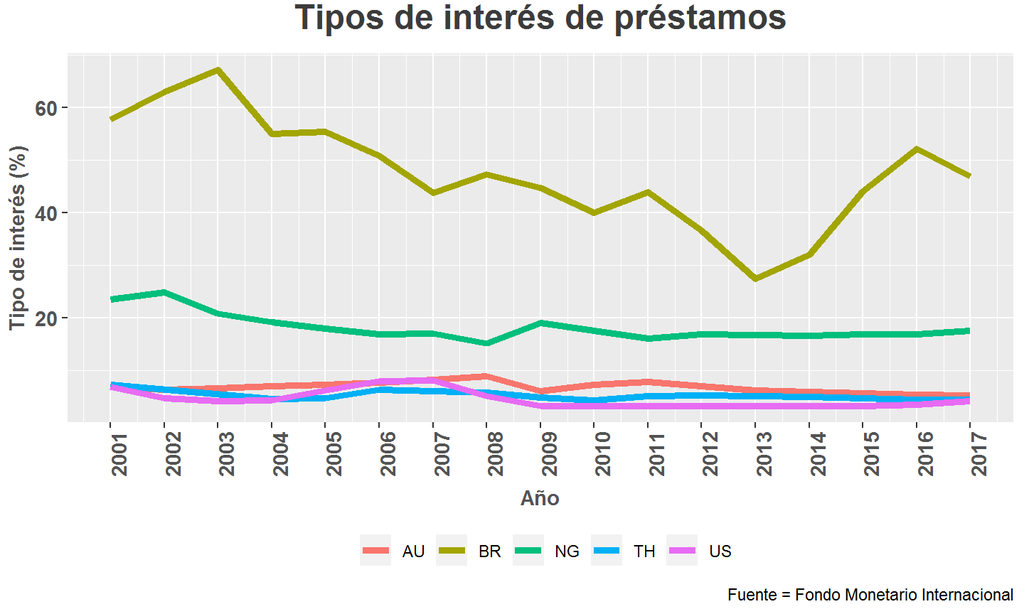

## Economías emergentes: Características

El coste de financiación es mucho mayor

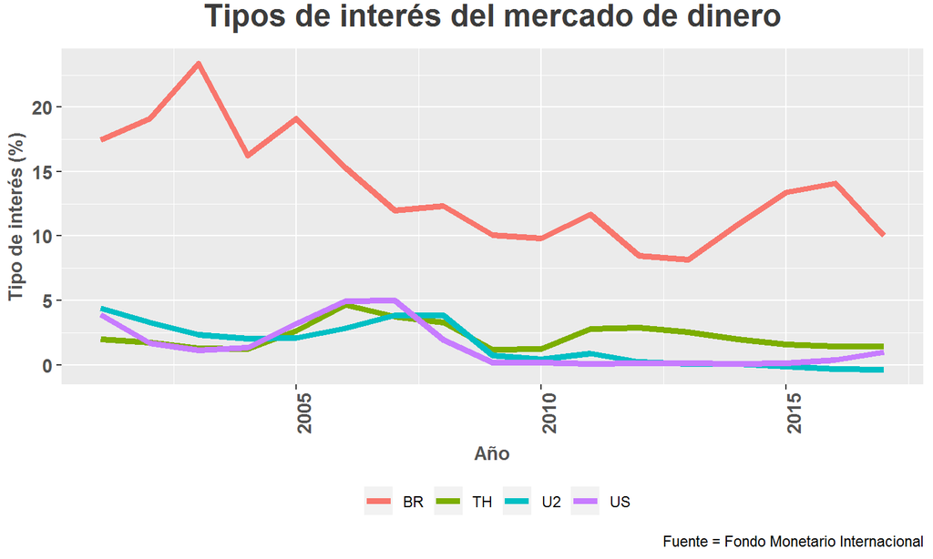

## Relato 1

- Aumentan los ingresos de gobierno, empresas y hogares
- Este efecto en el ingreso también impulsa el consumo privado
- Las personas van más al cine y compran más ropa y muebles, etc.
- Para satisfacer el aumento de la demanda, la inversión agregada también aumenta a medida que las empresas crecen, construyen más instalaciones y compran más maquinaria.

## Relato 1

- Entre tanto, otro elemento alimenta el fuego
- La economía adquieren mayor solvencia crediticia
- Pueden conseguir préstamos con tipos de interés más bajos.
- Atraídos por esa posibilidad, los gobiernos y las corporaciones en esos países se dirigen a Wall Street y a otros mercados internacionales de capital para pedir prestado, mediante la emisión de bonos

## Relato 1

- Hay más dinero que fluye en la economía, y el trayecto hacia arriba de la montaña rusa continúa con un PIB que crece sostenidamente, hasta llegar a un punto de inflexión
- Lo que sube rápidamente también puede bajar a toda velocidad, y esto es especialmente verdad cuando gran parte de la economía se encuentra estrechamente vinculada a los factores externos.

## Relato 1

[figure not shown]

## Relato 2

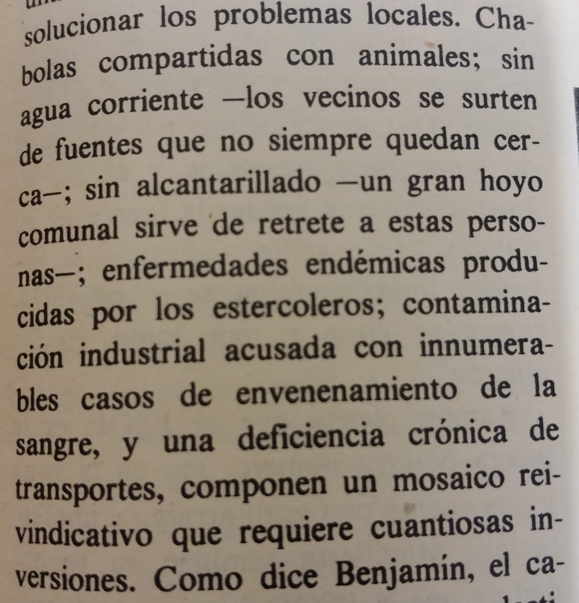